# P-Spline Mixed Effects Model

Laurens Bogaardt

2024-04-01

# Introduction

This document describes a simulation study of a mixed effects linear regression model with a 5-part P-spline as a fixed effect and a single random intercept per participant. First, the model is used to generate multiple datasets which are subsequently analysed to estimate the model’s parameters via maximum likelihood. Various estimation methods are used and compared. All methods result in the same estimates but some are computationally faster than others. The document uses the packages *tidyverse*, *JOPS*, *nlme*, *lme4*, *gamlss*, *mgcv* and *matrixStats*. And we set a seed to ensure each run of this document produces the same output.

```r
library(tidyverse)
library(JOPS)
library(nlme)
library(lme4)
library(gamlss)
library(mgcv)
library(matrixStats)
set.seed(123)
```

# Functions

The following function generates data for a mixed effects linear regression model. The subsequent functions estimate the parameters which best fit these data assuming the same model. This is done using multiple estimation methods which all result in the same maximum likelihood estimates.

```r
unlockBinding("ps", as.environment("package:gamlss"))
assign(
  x = "ps",
  value = function(x, df = 3, lambda = NULL, ps.intervals = 20, degree = 3, order = 3) {
    scall <- deparse(sys.call())
    if (is.null(lambda) & is.null(df))
        stop("df or lambda should be set \n")
    number.knots <- ps.intervals + 2 * degree + 1
    x.domain <- as.vector(x)
    xl <- min(x.domain)
    xr <- max(x.domain)
    xmax <- 1
    xmin <- 0
    dx <- (xmax - xmin)/ps.intervals
    nx <- names(x.domain)
    nax <- is.na(x.domain)
    if (nas <- any(nax))
        x.domain <- x[!nax]
    sorder <- degree + 1
    Aknots <- range(x.domain)
    nAknots <- ps.intervals - 1
    if (nAknots < 1) {
        nAknots <- 1
        warning(paste("ps.intervals was too small; have used 2"))
    }
    if (nAknots > 0) {
        Aknots <- seq(from = xmin - degree * dx, to = xmax +
            degree * dx, by = dx)
    }
    else knots <- NULL
    basis <- splineDesign(Aknots, x.domain, sorder, 0 * x.domain)
    n.col <- ncol(basis)
    dimnames(basis) <- list(1:nrow(basis), 1:n.col)
    if ((order - n.col + 1) > 0) {
        order <- n.col - 1
        warning(paste("order was too large; have used ", n.col -
            1))
    }
    if (df < 1)
        warning("the df are set to 1")
    df <- if (df < 1)
        1
    else df + 2
    if (!is.null(lambda)) {
        if (lambda < 0) {
            lambda <- 0
            warning(paste("lambda was negative; have used ",
                lambda))
        }
    }
    aug <- diag(n.col)
    if (order != 0) {
        for (tt in 1:order) {
            aug <- diff(aug)
        }
    }
    pen.aug <- aug
    xvar <- x
    attr(xvar, "knots") <- Aknots
    attr(xvar, "pen.augment") <- pen.aug
    attr(xvar, "design.matrix") <- basis
    attr(xvar, "call") <- substitute(gamlss.ps(data[[scall]],
        z, w))
    attr(xvar, "lambda") <- lambda
    attr(xvar, "df") <- df
    attr(xvar, "order") <- order
    xvar
  },
  env = as.environment("package:gamlss")
)
unlockBinding("smooth.construct.ps.smooth.spec", as.environment("package:mgcv"))
assign(
  x = "smooth.construct.ps.smooth.spec",
  value = function(object, data, knots){
    if (length(object$p.order) == 1)
        m <- rep(object$p.order, 2)
    else m <- object$p.order
    m[is.na(m)] <- 2
    object$p.order <- m
    if (object$bs.dim < 0)
        object$bs.dim <- max(10, m[1] + 1)
    nk <- object$bs.dim - m[1]
    if (nk <= 0)
        stop("basis dimension too small for b-spline order")
    if (length(object$term) != 1)
        stop("Basis only handles 1D smooths")
    x <- data[[object$term]]
    k <- knots[[object$term]]
    if (is.null(k)) {
        xl <- min(x)
        xu <- max(x)
    }
    else if (length(k) == 2) {
        xl <- min(k)
        xu <- max(k)
        if (xl > min(x) || xu < max(x))
            stop("knot range does not include data")
    }
    if (is.null(k) || length(k) == 2) {
        xr <- xu - xl
        xl <- 0
        xu <- 1
        dx <- (xu - xl)/(nk - 1)
        k <- seq(xl - dx * (m[1] + 1), xu + dx * (m[1] + 1),
            length = nk + 2 * m[1] + 2)
    }
    else {
        if (length(k) != nk + 2 * m[1] + 2)
            stop(paste("there should be ", nk + 2 * m[1] + 2,
                " supplied knots"))
    }
    if (is.null(object$deriv))
        object$deriv <- 0
    object$X <- splines::spline.des(k, x, m[1] + 2, x * 0 + object$deriv)$design
    if (!is.null(k)) {
        if (sum(colSums(object$X) == 0) > 0)
            warning("there is *no* information about some basis coefficients")
    }
    if (length(unique(x)) < object$bs.dim)
        warning("basis dimension is larger than number of unique covariates")
    if (is.null(object$mono))
        object$mono <- 0
    if (object$mono != 0) {
        p <- ncol(object$X)
        B <- matrix(as.numeric(rep(1:p, p) >= rep(1:p, each = p)),
            p, p)
        if (object$mono < 0)
            B[, 2:p] <- -B[, 2:p]
        object$D <- cbind(0, -diff(diag(p - 1)))
        if (object$mono == 2 || object$mono == -2) {
            object$D <- object$D[, -1]
            B <- B[, -1]
            object$null.space.dim <- 1
            object$g.index <- rep(TRUE, p - 1)
            object$C <- matrix(0, 0, ncol(object$X))
        }
        else {
            object$g.index <- c(FALSE, rep(TRUE, p - 1))
            object$null.space.dim <- 2
        }
        object$X <- object$X %*% B
        object$S <- list(crossprod(object$D))
        object$B <- B
        object$rank <- p - 2
    }
    else {
        object$D <- S <- if (m[2] > 0)
            diff(diag(object$bs.dim), differences = m[2])
        else diag(object$bs.dim)
        object$S <- list(crossprod(S))
        object$rank <- object$bs.dim - m[2]
        object$null.space.dim <- m[2]
    }
    object$knots <- k
    object$m <- m
    class(object) <- "pspline.smooth"
    object
  },
  envir = as.environment("package:mgcv")
)
```

```r
generate.data <- function(n.participants, n.measurements, fixed.coefficient.1, fixed.coefficient.2, fixed.coefficient.3, fixed.coefficient.4, fixed.coefficient.5, sd.random.intercept, sd.error, lambda) {
  participant.id <- factor(rep(seq(n.participants), each = n.measurements))
  x <- runif(n.participants * n.measurements)
  x[[1]] <- 0
  x[[length(x)]] <- 1
  x.matrix <- bbase(x, xl = 0, xr = 1, nseg = 2, bdeg = 3)
  fixed.effect <- c(x.matrix %*% c(fixed.coefficient.1, fixed.coefficient.2, fixed.coefficient.3, fixed.coefficient.4, fixed.coefficient.5))
  random.intercept <- rep(sd.random.intercept * rnorm(n.participants), each = n.measurements)
  y <- fixed.effect + random.intercept + sd.error * rnorm(n.participants * n.measurements)
  data <- data.frame(
    n.participants = n.participants,
    n.measurements = n.measurements,
    fixed.coefficient.1 = fixed.coefficient.1,
    fixed.coefficient.2 = fixed.coefficient.2,
    fixed.coefficient.3 = fixed.coefficient.3,
    fixed.coefficient.4 = fixed.coefficient.4,
    fixed.coefficient.5 = fixed.coefficient.5,
    sd.random.intercept = sd.random.intercept,
    sd.error = sd.error,
    participant.id = participant.id,
    x = x,
    y = y,
    lambda = lambda
  )
  return(data)
}
```

The following estimation method makes use of the *lme* function from the package *nlme*.

```r
estimate.model.and.get.coefficients.nlme <- function(data) {
  ptm <- proc.time()
  model <- lme(
    fixed = y ~ 0 + bbase(x, xl = 0, xr = 1, nseg = 2, bdeg = 3),
    data = data,
    random = ~ 1 | participant.id,
    method = "ML"
  )
  time <- proc.time() - ptm
  result <- c(
    fixed.coefficient.1 = fixef(model)[[1]],
    fixed.coefficient.2 = fixef(model)[[2]],
    fixed.coefficient.3 = fixef(model)[[3]],
    fixed.coefficient.4 = fixef(model)[[4]],
    fixed.coefficient.5 = fixef(model)[[5]],
    sd.random.intercept = as.numeric(VarCorr(model)[[3]]),
    sd.error = model$sigma,
    computation.time = time[[3]]
  )
  return(result)
}
```

The following estimation method makes use of the *lmer* function of the package *lme4*.

```r
estimate.model.and.get.coefficients.lme4 <- function(data) {
  ptm <- proc.time()
  model <- lmer(
    formula = y ~ 0 + bbase(x, xl = 0, xr = 1, nseg = 2, bdeg = 3) + (1 | participant.id),
    data = data,
    REML = FALSE
  )
  time <- proc.time() - ptm
  result <- c(
    fixed.coefficient.1 = fixef(model)[[1]],
    fixed.coefficient.2 = fixef(model)[[2]],
    fixed.coefficient.3 = fixef(model)[[3]],
    fixed.coefficient.4 = fixef(model)[[4]],
    fixed.coefficient.5 = fixef(model)[[5]],
    sd.random.intercept = sqrt(unlist(VarCorr(model)))[[1]],
    sd.error = summary(model)$sigma,
    computation.time = time[[3]]
  )
  return(result)
}
```

The following estimation method makes use of the *gamlss* function of the package *gamlss* and uses the *re* function to specify the random part of the model.

```r
# estimate.model.and.get.coefficients.gamlss1 <- function(data) {
#   data.gamlss1 <<- data
#   ptm <- proc.time()
#   model <- gamlss(
#     formula = y ~ 0 + re(fixed = ~ 0 + ps(x, df = 5, lambda = 0, ps.intervals = 2, degree = 3, order = 2), random = ~ 1 | participant.id),
#     sigma.formula = ~ 1,
#     family = NO(
#       mu.link = "identity",
#       sigma.link = "log"
#     ),
#     data = data.gamlss1,
#     trace = FALSE
#   )
#   time <- proc.time() - ptm
#   fixed.coef <- coef(lm(predict(model, type = "terms")[,1] ~ 0 + bbase(data$x, xl = 0, xr = 1, nseg = 2, bdeg = 3)))
#   result <- c(
#     fixed.coefficient.1 = fixed.coef[[1]],
#     fixed.coefficient.2 = fixed.coef[[2]],
#     fixed.coefficient.3 = fixed.coef[[3]],
#     fixed.coefficient.4 = fixed.coef[[4]],
#     fixed.coefficient.5 = fixed.coef[[5]],
#     sd.random.intercept = as.numeric(VarCorr(getSmo(model))[[3]]),
#     sd.error = as.numeric(VarCorr(getSmo(model))[[4]]) * exp(model[["sigma.coefficients"]][["(Intercept)"]]),
#     time = time[[3]]
#   )
#   return(result)
# }
```

The following estimation method makes use of the *gamlss* function of the package *gamlss* and uses the *random* function to specify the random part of the model.

```r
estimate.model.and.get.coefficients.gamlss2 <- function(data) { # https://rdrr.io/cran/gamlss/src/R/PS.R
  data.gamlss2 <<- data
  lambda <- data$lambda[[1]]
  ptm <- proc.time()
  model <- gamlss(
    formula = formula(paste0("y ~ 0 + ps(x, df = 5, lambda = ", lambda, ", ps.intervals = 2, degree = 3, order = 2) + random(participant.id)")),
    sigma.formula = ~ 1,
    family = NO(
      mu.link = "identity",
      sigma.link = "log"
    ),
    data = data.gamlss2,
    trace = FALSE
  )
  time <- proc.time() - ptm
  fixed.coef <- coef(lm(predict(model, type = "terms")[,1] ~ 0 + bbase(data$x, xl = 0, xr = 1, nseg = 2, bdeg = 3)))
  result <- c(
    fixed.coefficient.1 = fixed.coef[[1]],
    fixed.coefficient.2 = fixed.coef[[2]],
    fixed.coefficient.3 = fixed.coef[[3]],
    fixed.coefficient.4 = fixed.coef[[4]],
    fixed.coefficient.5 = fixed.coef[[5]],
    sd.random.intercept = model[["mu.coefSmo"]][[2]][["sigb"]],
    sd.error = model[["mu.coefSmo"]][[2]][["sige"]] * exp(model$sigma.coefficients[[1]]),
    computation.time = time[[3]]
  )
  return(result)
}
```

The following estimation method makes use of the *gam* function of the package *mgcv*.

```r
# estimate.model.and.get.coefficients.mgcv <- function(data) {
#   ptm <- proc.time()
#   model <- gam(
#     formula = y ~ 0 + s(x, k = 5, bs = "ps", m = c(2, 2), sp = 0) + s(participant.id, bs = "re"),
#     data = data,
#     method = "ML"
#   )
#   time <- proc.time() - ptm
#   fixed.coef <- coef(model)[[1]] + coef(lm(predict(model, type = "terms")[,1] ~ 0 + bbase(data$x, xl = 0, xr = 1, nseg = 2, bdeg = 3)))
#   invisible(
#     capture.output(
#       result <- c(
#         fixed.coefficient.1 = fixed.coef[[1]],
#         fixed.coefficient.2 = fixed.coef[[2]],
#         fixed.coefficient.3 = fixed.coef[[3]],
#         fixed.coefficient.4 = fixed.coef[[4]],
#         fixed.coefficient.5 = fixed.coef[[5]],
#         sd.random.intercept = gam.vcomp(model)[[1]],
#         sd.error = gam.vcomp(model)[[2]],
#         time = time[[3]]
#       )
#     )
#   )
#   return(result)
# }
```

The following estimation method uses a custom likelihood function which is optimised using the function *optim* and which also makes use of the function *logSumExp* from the package *matrixStats*.

```r
estimate.model.and.get.coefficients.optim <- function(data) {
  fixed.coefficient.1 <- data$fixed.coefficient.1[[1]]
  fixed.coefficient.2 <- data$fixed.coefficient.2[[1]]
  fixed.coefficient.3 <- data$fixed.coefficient.3[[1]]
  fixed.coefficient.4 <- data$fixed.coefficient.4[[1]]
  fixed.coefficient.5 <- data$fixed.coefficient.5[[1]]
  sd.random.intercept <- data$sd.random.intercept[[1]]
  sd.error <- data$sd.error[[1]]
  participant.id <- data$participant.id
  lambda <- data$lambda[[1]] / 2 # WHY?
  p.matrix <- lambda * t(diff(diag(5), diff = 2)) %*% diff(diag(5), diff = 2)
  fun.ri <- function(i, y, fixed.effect, log.sd.random.intercept, log.sd.error) {
    -sum(((fixed.effect + exp(log.sd.random.intercept) * i - y) / exp(log.sd.error)) ^ 2 / 2 + log.sd.error + log(2 * pi) / 2) - i ^ 2 / 2 - log(2 * pi) / 2 - log(20)
  }
  ri <- seq(-4, 4, 0.05)
  fun.split <- function(split.data, par) {
    x <- split.data$x
    y <- split.data$y
    x.matrix <- bbase(x, xl = 0, xr = 1, nseg = 2, bdeg = 3)
    fixed.effect <- c(x.matrix %*% par[seq(5)])
    log.sd.random.intercept <- par[[6]]
    log.sd.error <- par[[7]]
    logSumExp(sapply(ri, fun.ri, y, fixed.effect, log.sd.random.intercept, log.sd.error))
  }
  data.split <- split(data[c("x", "y")], participant.id)
  fun.optim <- function(par) {
    penalty <- c(t(p.matrix %*% par[seq(5)]) %*% par[seq(5)])
    -sum(sapply(data.split, fun.split, par)) + penalty
  }
  ptm <- proc.time()
  model <- optim(
    par = c(fixed.coefficient.1, fixed.coefficient.2, fixed.coefficient.3, fixed.coefficient.4, fixed.coefficient.5, log(sd.random.intercept), log(sd.error)),
    fn = fun.optim,
    method = "BFGS"
  )
  time <- proc.time() - ptm
  result <- c(
    fixed.coefficient.1 = model$par[[1]],
    fixed.coefficient.2 = model$par[[2]],
    fixed.coefficient.3 = model$par[[3]],
    fixed.coefficient.4 = model$par[[4]],
    fixed.coefficient.5 = model$par[[5]],
    sd.random.intercept = exp(model$par[[6]]),
    sd.error = exp(model$par[[7]]),
    computation.time = time[[3]]
  )
  return(result)
}
```

The following estimation method uses an analytic expression for the least-squares estimates assuming a fixed standard deviation for the random intercept, and uses a custom likelihood function which is optimised using the function *optimise* to find the best fitting standard deviation of the random intercept.

```r
estimate.model.and.get.coefficients.gls <- function(data) {
  n.participants <- data$n.participants[[1]]
  n.measurements <- data$n.measurements[[1]]
  x <- data$x
  y <- data$y
  lambda <- data$lambda[[1]]
  x.matrix <- bbase(x, xl = 0, xr = 1, nseg = 2, bdeg = 3)
  p.matrix <- lambda * t(diff(diag(5), diff = 2)) %*% diff(diag(5), diff = 2)
  fun.gls <- function(ratio) {
    correlation.matrix <- bdiag(replicate(n.participants, (diag(1 - ratio, n.measurements) + matrix(ratio, n.measurements, n.measurements)), simplify = FALSE))
    inverse.correlation.matrix <- solve(correlation.matrix, diag(n.participants * n.measurements))
    partial.matrix <- t(x.matrix) %*% inverse.correlation.matrix %*% x.matrix + p.matrix
    inverse.partial.matrix <- solve(partial.matrix, diag(dim(partial.matrix)[[1]]))
    fixed.coefficients <- inverse.partial.matrix %*% t(x.matrix) %*% inverse.correlation.matrix %*% y
    residuals <- y - x.matrix %*% fixed.coefficients
    var.residuals <- var(as.vector(residuals))

    partial.matrix <- t(x.matrix) %*% inverse.correlation.matrix %*% x.matrix + p.matrix / var.residuals
    inverse.partial.matrix <- solve(partial.matrix, diag(dim(partial.matrix)[[1]]))
    fixed.coefficients <- inverse.partial.matrix %*% t(x.matrix) %*% inverse.correlation.matrix %*% y
    residuals <- y - x.matrix %*% fixed.coefficients
    var.residuals <- var(as.vector(residuals))
    partial.matrix <- t(x.matrix) %*% inverse.correlation.matrix %*% x.matrix + p.matrix / var.residuals
    inverse.partial.matrix <- solve(partial.matrix, diag(dim(partial.matrix)[[1]]))
    fixed.coefficients <- inverse.partial.matrix %*% t(x.matrix) %*% inverse.correlation.matrix %*% y
    residuals <- y - x.matrix %*% fixed.coefficients
    var.residuals <- var(as.vector(residuals))
    partial.matrix <- t(x.matrix) %*% inverse.correlation.matrix %*% x.matrix + p.matrix / var.residuals
    inverse.partial.matrix <- solve(partial.matrix, diag(dim(partial.matrix)[[1]]))
    fixed.coefficients <- inverse.partial.matrix %*% t(x.matrix) %*% inverse.correlation.matrix %*% y
    residuals <- y - x.matrix %*% fixed.coefficients
    var.residuals <- var(as.vector(residuals))
    partial.matrix <- t(x.matrix) %*% inverse.correlation.matrix %*% x.matrix + p.matrix / var.residuals
    inverse.partial.matrix <- solve(partial.matrix, diag(dim(partial.matrix)[[1]]))
    fixed.coefficients <- inverse.partial.matrix %*% t(x.matrix) %*% inverse.correlation.matrix %*% y
    residuals <- y - x.matrix %*% fixed.coefficients
    var.residuals <- var(as.vector(residuals))
    partial.matrix <- t(x.matrix) %*% inverse.correlation.matrix %*% x.matrix + p.matrix / var.residuals
    inverse.partial.matrix <- solve(partial.matrix, diag(dim(partial.matrix)[[1]]))
    fixed.coefficients <- inverse.partial.matrix %*% t(x.matrix) %*% inverse.correlation.matrix %*% y
    residuals <- y - x.matrix %*% fixed.coefficients
    var.residuals <- var(as.vector(residuals))
    partial.matrix <- t(x.matrix) %*% inverse.correlation.matrix %*% x.matrix + p.matrix / var.residuals
    inverse.partial.matrix <- solve(partial.matrix, diag(dim(partial.matrix)[[1]]))
    fixed.coefficients <- inverse.partial.matrix %*% t(x.matrix) %*% inverse.correlation.matrix %*% y
    residuals <- y - x.matrix %*% fixed.coefficients
    var.residuals <- var(as.vector(residuals))
    partial.matrix <- t(x.matrix) %*% inverse.correlation.matrix %*% x.matrix + p.matrix / var.residuals
    inverse.partial.matrix <- solve(partial.matrix, diag(dim(partial.matrix)[[1]]))
    fixed.coefficients <- inverse.partial.matrix %*% t(x.matrix) %*% inverse.correlation.matrix %*% y
    residuals <- y - x.matrix %*% fixed.coefficients
    var.residuals <- var(as.vector(residuals))
    partial.matrix <- t(x.matrix) %*% inverse.correlation.matrix %*% x.matrix + p.matrix / var.residuals
    inverse.partial.matrix <- solve(partial.matrix, diag(dim(partial.matrix)[[1]]))
    fixed.coefficients <- inverse.partial.matrix %*% t(x.matrix) %*% inverse.correlation.matrix %*% y
    residuals <- y - x.matrix %*% fixed.coefficients
    var.residuals <- var(as.vector(residuals))
    partial.matrix <- t(x.matrix) %*% inverse.correlation.matrix %*% x.matrix + p.matrix / var.residuals
    inverse.partial.matrix <- solve(partial.matrix, diag(dim(partial.matrix)[[1]]))
    fixed.coefficients <- inverse.partial.matrix %*% t(x.matrix) %*% inverse.correlation.matrix %*% y
    residuals <- y - x.matrix %*% fixed.coefficients
    var.residuals <- var(as.vector(residuals))

    chol.matrix <- chol(var.residuals * correlation.matrix)
    log.sqrt.det <- sum(log(diag(chol.matrix)))
    loglikelihood <- rowSums(-t(p.matrix %*% fixed.coefficients) %*% fixed.coefficients - 0.5 * t(residuals) %*% inverse.correlation.matrix %*% residuals) / var.residuals - log.sqrt.det - log(2 * pi) * (n.participants * n.measurements / 2)
    return(loglikelihood)
  }
  ptm <- proc.time()
  optimise.correlation.gls <- optimise(
    f = fun.gls,
    interval = c(0.0001, 0.9999),
    maximum = TRUE
  )
  ratio <- optimise.correlation.gls$maximum
  correlation.matrix <- bdiag(replicate(n.participants, (diag(1 - ratio, n.measurements) + matrix(ratio, n.measurements, n.measurements)), simplify = FALSE))
  inverse.correlation.matrix <- solve(correlation.matrix, diag(n.participants * n.measurements))
  partial.matrix <- t(x.matrix) %*% inverse.correlation.matrix %*% x.matrix + p.matrix
  inverse.partial.matrix <- solve(partial.matrix, diag(dim(partial.matrix)[[1]]))
  fixed.coefficients <- inverse.partial.matrix %*% t(x.matrix) %*% inverse.correlation.matrix %*% y
  residuals <- x.matrix %*% fixed.coefficients - y
  sd <- sd(residuals)

  partial.matrix <- t(x.matrix) %*% inverse.correlation.matrix %*% x.matrix + p.matrix / sd / sd
  inverse.partial.matrix <- solve(partial.matrix, diag(dim(partial.matrix)[[1]]))
  fixed.coefficients <- inverse.partial.matrix %*% t(x.matrix) %*% inverse.correlation.matrix %*% y
  residuals <- x.matrix %*% fixed.coefficients - y
  sd <- sd(residuals)
  partial.matrix <- t(x.matrix) %*% inverse.correlation.matrix %*% x.matrix + p.matrix / sd / sd
  inverse.partial.matrix <- solve(partial.matrix, diag(dim(partial.matrix)[[1]]))
  fixed.coefficients <- inverse.partial.matrix %*% t(x.matrix) %*% inverse.correlation.matrix %*% y
  residuals <- x.matrix %*% fixed.coefficients - y
  sd <- sd(residuals)
  partial.matrix <- t(x.matrix) %*% inverse.correlation.matrix %*% x.matrix + p.matrix / sd / sd
  inverse.partial.matrix <- solve(partial.matrix, diag(dim(partial.matrix)[[1]]))
  fixed.coefficients <- inverse.partial.matrix %*% t(x.matrix) %*% inverse.correlation.matrix %*% y
  residuals <- x.matrix %*% fixed.coefficients - y
  sd <- sd(residuals)
  partial.matrix <- t(x.matrix) %*% inverse.correlation.matrix %*% x.matrix + p.matrix / sd / sd
  inverse.partial.matrix <- solve(partial.matrix, diag(dim(partial.matrix)[[1]]))
  fixed.coefficients <- inverse.partial.matrix %*% t(x.matrix) %*% inverse.correlation.matrix %*% y
  residuals <- x.matrix %*% fixed.coefficients - y
  sd <- sd(residuals)
  partial.matrix <- t(x.matrix) %*% inverse.correlation.matrix %*% x.matrix + p.matrix / sd / sd
  inverse.partial.matrix <- solve(partial.matrix, diag(dim(partial.matrix)[[1]]))
  fixed.coefficients <- inverse.partial.matrix %*% t(x.matrix) %*% inverse.correlation.matrix %*% y
  residuals <- x.matrix %*% fixed.coefficients - y
  sd <- sd(residuals)
  partial.matrix <- t(x.matrix) %*% inverse.correlation.matrix %*% x.matrix + p.matrix / sd / sd
  inverse.partial.matrix <- solve(partial.matrix, diag(dim(partial.matrix)[[1]]))
  fixed.coefficients <- inverse.partial.matrix %*% t(x.matrix) %*% inverse.correlation.matrix %*% y
  residuals <- x.matrix %*% fixed.coefficients - y
  sd <- sd(residuals)
  partial.matrix <- t(x.matrix) %*% inverse.correlation.matrix %*% x.matrix + p.matrix / sd / sd
  inverse.partial.matrix <- solve(partial.matrix, diag(dim(partial.matrix)[[1]]))
  fixed.coefficients <- inverse.partial.matrix %*% t(x.matrix) %*% inverse.correlation.matrix %*% y
  residuals <- x.matrix %*% fixed.coefficients - y
  sd <- sd(residuals)
  partial.matrix <- t(x.matrix) %*% inverse.correlation.matrix %*% x.matrix + p.matrix / sd / sd
  inverse.partial.matrix <- solve(partial.matrix, diag(dim(partial.matrix)[[1]]))
  fixed.coefficients <- inverse.partial.matrix %*% t(x.matrix) %*% inverse.correlation.matrix %*% y
  residuals <- x.matrix %*% fixed.coefficients - y
  sd <- sd(residuals)
  partial.matrix <- t(x.matrix) %*% inverse.correlation.matrix %*% x.matrix + p.matrix / sd / sd
  inverse.partial.matrix <- solve(partial.matrix, diag(dim(partial.matrix)[[1]]))
  fixed.coefficients <- inverse.partial.matrix %*% t(x.matrix) %*% inverse.correlation.matrix %*% y
  residuals <- x.matrix %*% fixed.coefficients - y
  sd <- sd(residuals)

  sd.random.intercept <- sqrt(ratio) * sd
  sd.error <- sqrt(1 - ratio) * sd
  time <- proc.time() - ptm
  result <- c(
    fixed.coefficient.1 = rowSums(fixed.coefficients)[[1]],
    fixed.coefficient.2 = rowSums(fixed.coefficients)[[2]],
    fixed.coefficient.3 = rowSums(fixed.coefficients)[[3]],
    fixed.coefficient.4 = rowSums(fixed.coefficients)[[4]],
    fixed.coefficient.5 = rowSums(fixed.coefficients)[[5]],
    sd.random.intercept = sd.random.intercept,
    sd.error = sd.error,
    computation.time = time[[3]]
  )
  return(result)
}
```

The following function combines all previous estimation functions to be able to estimate and compare model parameters on the same input dataset.

```r
estimate.all.models.and.get.coefficients <- function(data) {
  result <- data.frame(
    method = c("gamlss2", "optim", "gls"),
    rbind(
      # estimate.model.and.get.coefficients.nlme(data),
      # estimate.model.and.get.coefficients.lme4(data),
      # estimate.model.and.get.coefficients.gamlss1(data),
      estimate.model.and.get.coefficients.gamlss2(data),
      # estimate.model.and.get.coefficients.mgcv(data),
      estimate.model.and.get.coefficients.optim(data),
      estimate.model.and.get.coefficients.gls(data)
    )
  )
  return(result)
}
```

# Parameters

The mixed effects linear regression takes various input parameters. These can all be varied, one by one, which results in a table of input parameters on which the simulation study is performed.

```r
parameters <- tibble(
  parameter.set = seq(8),
  n.participants = c(100, 100, 400, 100, 100, 100, 100, 100),
  n.measurements = c(4, 4, 4, 8, 4, 4, 4, 4),
  fixed.coefficient.1 = c(1, 1, 1, 1, -0.5, 1, 1, 1),
  fixed.coefficient.2 = c(-1, -1, -1, -1, 0.5, -1, -1, -1),
  fixed.coefficient.3 = c(2, 2, 2, 2, 1.5, 2, 2, 2),
  fixed.coefficient.4 = c(1, 1, 1, 1, -0.5, 1, 1, 1),
  fixed.coefficient.5 = c(0, 0, 0, 0, 0.5, 0, 0, 0),
  sd.random.intercept = c(0.5, 0.5, 0.5, 0.5, 0.5, 0.75, 0.5, 0.5),
  sd.error = c(1, 1, 1, 1, 1, 1, 0.75, 1),
  lambda = c(0, 1, 1, 1, 1, 1, 1, 10)
)
parameters
```

| parameter.set | n.participants | n.measurements | fixed.coefficient.1 | fixed.coefficient.2 | fixed.coefficient.3 | fixed.coefficient.4 | fixed.coefficient.5 | sd.random.intercept | sd.error | lambda |
| --- | --- | --- | --- | --- | --- | --- | --- | --- | --- | --- |
| 1 | 100 | 4 | 1.0 | -1.0 | 2.0 | 1.0 | 0.0 | 0.50 | 1.00 | 0 |
| 2 | 100 | 4 | 1.0 | -1.0 | 2.0 | 1.0 | 0.0 | 0.50 | 1.00 | 1 |
| 3 | 400 | 4 | 1.0 | -1.0 | 2.0 | 1.0 | 0.0 | 0.50 | 1.00 | 1 |
| 4 | 100 | 8 | 1.0 | -1.0 | 2.0 | 1.0 | 0.0 | 0.50 | 1.00 | 1 |
| 5 | 100 | 4 | -0.5 | 0.5 | 1.5 | -0.5 | 0.5 | 0.50 | 1.00 | 1 |
| 6 | 100 | 4 | 1.0 | -1.0 | 2.0 | 1.0 | 0.0 | 0.75 | 1.00 | 1 |
| 7 | 100 | 4 | 1.0 | -1.0 | 2.0 | 1.0 | 0.0 | 0.50 | 0.75 | 1 |
| 8 | 100 | 4 | 1.0 | -1.0 | 2.0 | 1.0 | 0.0 | 0.50 | 1.00 | 10 |

# Estimation

For each set of input parameters, the generation and estimation procedure is applied multiple times. Every run results in slightly different estimates but all methods should produce the same values. These are compared below.

```r
estimated.parameters <- parameters %>%
  expand_grid(
    run = seq(5)
  ) %>%
  reframe(
    generate.data(
      n.participants = n.participants,
      n.measurements = n.measurements,
      fixed.coefficient.1 = fixed.coefficient.1,
      fixed.coefficient.2 = fixed.coefficient.2,
      fixed.coefficient.3 = fixed.coefficient.3,
      fixed.coefficient.4 = fixed.coefficient.4,
      fixed.coefficient.5 = fixed.coefficient.5,
      sd.random.intercept = sd.random.intercept,
      sd.error = sd.error,
      lambda = lambda
    ) %>%
      estimate.all.models.and.get.coefficients(),
    .by = c(parameter.set, run)
  )
estimated.parameters
```

| parameter.set | run | method | fixed.coefficient.1 | fixed.coefficient.2 | fixed.coefficient.3 | fixed.coefficient.4 | fixed.coefficient.5 | sd.random.intercept | sd.error | computation.time |
| --- | --- | --- | --- | --- | --- | --- | --- | --- | --- | --- |
| 1 | 1 | gamlss2 | -1.8432577 | -0.308754963 | 1.694825 | 1.27040481 | -0.713799637 | 0.3435051 | 1.0353268 | 0.35 |
| 1 | 1 | optim | -1.8655932 | -0.304181374 | 1.692098 | 1.27460940 | -0.734310707 | 0.3436805 | 1.0353339 | 27.99 |
| 1 | 1 | gls | -1.8414588 | -0.308966124 | 1.694818 | 1.27055990 | -0.714543379 | 0.3444250 | 1.0364623 | 1.57 |
| 1 | 2 | gamlss2 | 1.5787078 | -1.523232935 | 2.256721 | 0.57496956 | 4.520943604 | 0.5039520 | 0.9874798 | 0.19 |
| 1 | 2 | optim | 1.6017410 | -1.527601195 | 2.260056 | 0.56977411 | 4.542197275 | 0.5044355 | 0.9875725 | 23.22 |
| 1 | 2 | gls | 1.5863383 | -1.524445237 | 2.257307 | 0.57419684 | 4.523808091 | 0.5053223 | 0.9883473 | 1.13 |
| 1 | 3 | gamlss2 | 1.2161317 | -0.944461352 | 1.988042 | 1.11767334 | 0.651829812 | 0.5284653 | 1.0393731 | 0.15 |
| 1 | 3 | optim | 1.2176810 | -0.944582936 | 1.988298 | 1.11732018 | 0.654018783 | 0.5288901 | 1.0393783 | 23.02 |
| 1 | 3 | gls | 1.2159330 | -0.944310332 | 1.987937 | 1.11777120 | 0.651317024 | 0.5298918 | 1.0402861 | 1.09 |
| 1 | 4 | gamlss2 | 4.9734526 | -1.526446877 | 2.171813 | 1.01204263 | -0.726068242 | 0.4342009 | 0.9858027 | 0.18 |

[output cut: 110 more lines]

# Compare Estimates

```r
# ggplot(
#   mapping = aes(
#     x = nlme,
#     y = lme4
#   ),
#   data = estimated.parameters %>%
#     select(-time) %>%
#     pivot_longer(c("fixed.coefficient.1", "fixed.coefficient.2", "fixed.coefficient.3", "fixed.coefficient.4", "fixed.coefficient.5", "sd.random.intercept", "sd.error")) %>%
#     pivot_wider(names_from = "method"),
#     alpha = 0.1
# ) +
#   geom_point() +
#   geom_smooth(
#     formula = y ~ x,
#     method = "lm",
#     col = "green"
#   ) +
#   geom_abline(
#     intercept = 0,
#     slope = 1
#   ) +
#   facet_grid(
#     cols = vars(name),
#     rows = vars(parameter.set),
#     scales = "free"
#   )
```

```r
# ggplot(
#   mapping = aes(
#     x = nlme,
#     y = gamlss1
#   ),
#   data = estimated.parameters %>%
#     select(-time) %>%
#     pivot_longer(c("fixed.coefficient.1", "fixed.coefficient.2", "fixed.coefficient.3", "fixed.coefficient.4", "fixed.coefficient.5", "sd.random.intercept", "sd.error")) %>%
#     pivot_wider(names_from = "method"),
#     alpha = 0.1
# ) +
#   geom_point() +
#   geom_smooth(
#     formula = y ~ x,
#     method = "lm",
#     col = "green"
#   ) +
#   geom_abline(
#     intercept = 0,
#     slope = 1
#   ) +
#   facet_grid(
#     cols = vars(name),
#     rows = vars(parameter.set),
#     scales = "free"
#   )
```

```r
# ggplot(
#   mapping = aes(
#     x = nlme,
#     y = gamlss2
#   ),
#   data = estimated.parameters %>%
#     select(-time) %>%
#     pivot_longer(c("fixed.coefficient.1", "fixed.coefficient.2", "fixed.coefficient.3", "fixed.coefficient.4", "fixed.coefficient.5", "sd.random.intercept", "sd.error")) %>%
#     pivot_wider(names_from = "method"),
#     alpha = 0.1
# ) +
#   geom_point() +
#   geom_smooth(
#     formula = y ~ x,
#     method = "lm",
#     col = "green"
#   ) +
#   geom_abline(
#     intercept = 0,
#     slope = 1
#   ) +
#   facet_grid(
#     cols = vars(name),
#     rows = vars(parameter.set),
#     scales = "free"
#   )
```

Let’s now compare the methods from *optim* and *gls*.

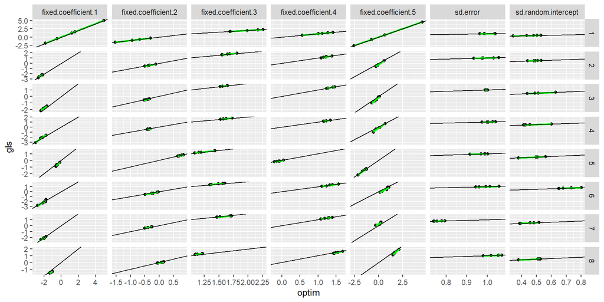

```r
ggplot(
  mapping = aes(
    x = optim,
    y = gls
  ),
  data = estimated.parameters %>%
    select(-computation.time) %>%
    pivot_longer(c("fixed.coefficient.1", "fixed.coefficient.2", "fixed.coefficient.3", "fixed.coefficient.4", "fixed.coefficient.5", "sd.random.intercept", "sd.error")) %>%
    pivot_wider(names_from = "method"),
    alpha = 0.1
) +
  geom_point() +
  geom_smooth(
    formula = y ~ x,
    method = "lm",
    col = "green"
  ) +
  geom_abline(
    intercept = 0,
    slope = 1
  ) +
  facet_grid(
    cols = vars(name),
    rows = vars(parameter.set),
    scales = "free"
  )
```

Let’s now compare the methods from *gamlss2* and *optim*.

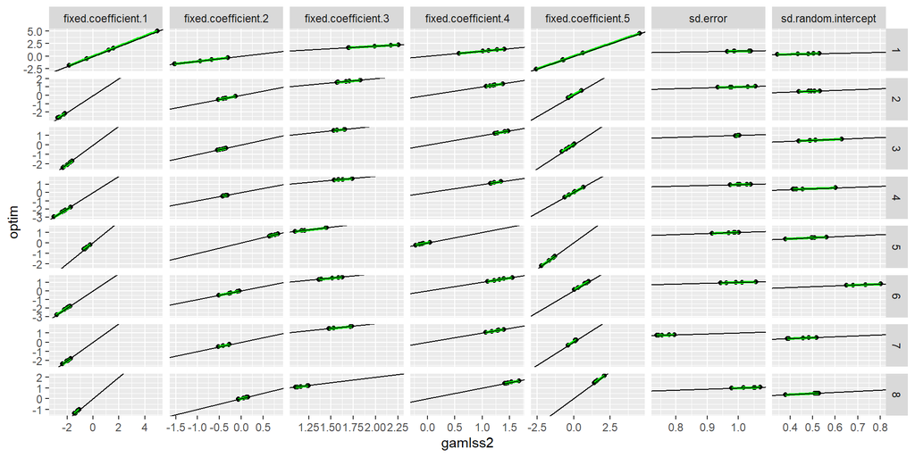

```r
ggplot(
  mapping = aes(
    x = gamlss2,
    y = optim
  ),
  data = estimated.parameters %>%
    select(-computation.time) %>%
    pivot_longer(c("fixed.coefficient.1", "fixed.coefficient.2", "fixed.coefficient.3", "fixed.coefficient.4", "fixed.coefficient.5", "sd.random.intercept", "sd.error")) %>%
    pivot_wider(names_from = "method"),
    alpha = 0.1
) +
  geom_point() +
  geom_smooth(
    formula = y ~ x,
    method = "lm",
    col = "green"
  ) +
  geom_abline(
    intercept = 0,
    slope = 1
  ) +
  facet_grid(
    cols = vars(name),
    rows = vars(parameter.set),
    scales = "free"
  )
```

Finally, let’s compare the methods from *gamlss2* and *gls*.

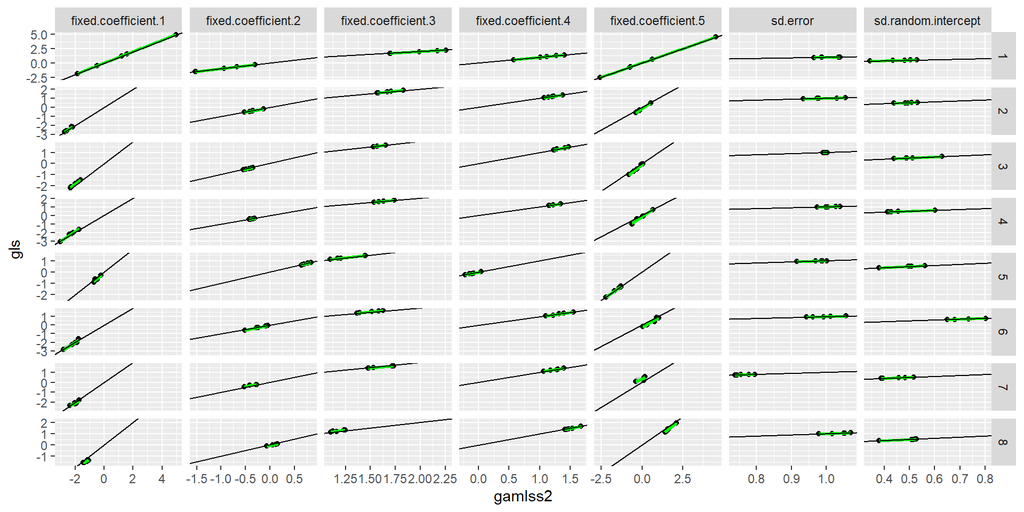

```r
ggplot(
  mapping = aes(
    x = gamlss2,
    y = gls
  ),
  data = estimated.parameters %>%
    select(-computation.time) %>%
    pivot_longer(c("fixed.coefficient.1", "fixed.coefficient.2", "fixed.coefficient.3", "fixed.coefficient.4", "fixed.coefficient.5", "sd.random.intercept", "sd.error")) %>%
    pivot_wider(names_from = "method"),
    alpha = 0.1
) +
  geom_point() +
  geom_smooth(
    formula = y ~ x,
    method = "lm",
    col = "green"
  ) +
  geom_abline(
    intercept = 0,
    slope = 1
  ) +
  facet_grid(
    cols = vars(name),
    rows = vars(parameter.set),
    scales = "free"
  )
```

All methods give the same result. Only the *optim* method, which estimated the model using a custom likelihood function, gave slightly different result. This is probably due to the low resolution of the numerical integration used in this method, and not due to a fundamental difference in the model.

# Compare Computation Time

We have seen that all methods produce the same estimates. However, some methods are computationally faster than others. The table below provides the mean estimation time.

```r
estimated.parameters %>%
  group_by(parameter.set, method) %>%
  summarise(
    computation.time = mean(computation.time),
    .groups = "drop"
  ) %>%
  pivot_wider(
    values_from = computation.time,
    names_from = method
  )
```

| parameter.set | gamlss2 | gls | optim |
| --- | --- | --- | --- |
| 1 | 0.206 | 1.234 | 24.264 |
| 2 | 0.316 | 1.254 | 17.514 |
| 3 | 1.090 | 7.728 | 70.044 |
| 4 | 0.254 | 1.980 | 17.484 |
| 5 | 0.274 | 1.050 | 16.220 |
| 6 | 0.200 | 1.068 | 16.952 |
| 7 | 0.246 | 1.030 | 17.438 |
| 8 | 0.338 | 1.128 | 20.650 |

The computation times can also be plot as densities.

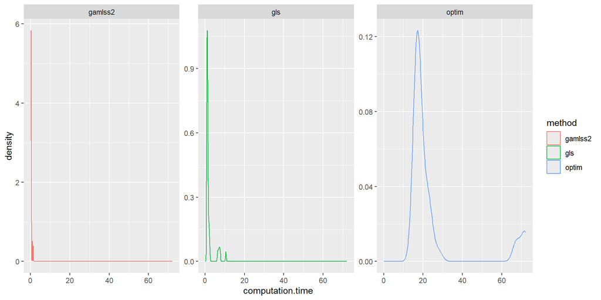

```r
ggplot() +
  geom_density(
    mapping = aes(
      x = computation.time,
      col = method
    ),
    data = estimated.parameters
  ) +
  facet_wrap(
    facets = ~ method,
    scales = "free_y"
  )
```

# Visualise Curves

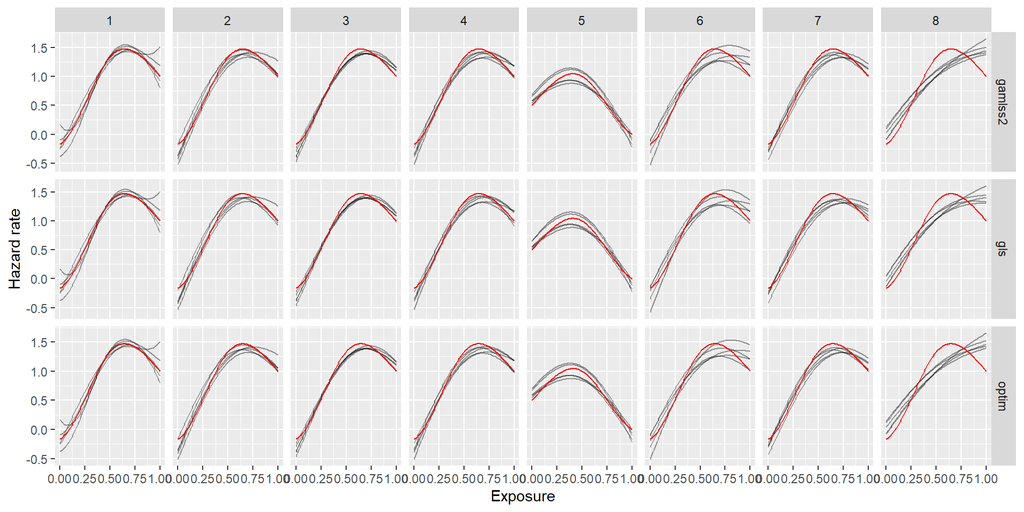

```r
ggplot() +
  geom_line(
    mapping = aes(
      x = x,
      y = y,
      group = run
    ),
    data = estimated.parameters %>%
      filter(!is.na(computation.time)) %>%
      group_by(parameter.set, run, method) %>%
      reframe(
        x = seq(0, 1, 0.01),
        y = c(bbase(x, xl = 0, xr = 1, nseg = 2, bdeg = 3) %*% c(fixed.coefficient.1, fixed.coefficient.2, fixed.coefficient.3, fixed.coefficient.4, fixed.coefficient.5))
      ),
    alpha = 0.4
  ) +
  geom_line(
    mapping = aes(
      x = x,
      y = y
    ),
    data = parameters %>%
      group_by(parameter.set) %>%
      reframe(
        x = seq(0, 1, 0.01),
        y = c(bbase(x, xl = 0, xr = 1, nseg = 2, bdeg = 3) %*% c(fixed.coefficient.1, fixed.coefficient.2, fixed.coefficient.3, fixed.coefficient.4, fixed.coefficient.5))
      ),
    colour = "red"
  ) +
  facet_grid(
    rows = vars(method),
    cols = vars(parameter.set),
    scales = "free"
  ) +
  labs(
    x = "Exposure",
    y = "Hazard rate"
  )
```